# Final Project

Feng Ding

12/15/2019

Introduction: For the final project, I used the skills that STAT 184 introduced to analyze the area of my interest which is music. I used data wrangling skills to get the data graph ready and then use different types of graphs to present the result and therefore answer the research questions. The questions are mainly about the popularity of music genres in recent years.

Note: Given that the project is mainly for practice purpose, I choosed two synthetically generated music dataset for a small imaginary Music Lables. Therefore, any conclusions in the project report should not be considered as related to real life situations.

### Clean up environment and load packages

```r
# clean up the RStudio environment
rm(list = ls())

# load all packages here
library(dplyr)
library(tidyverse)
```

```r
library(ggplot2)
library(tibble)
```

### Data Intake

```r
# The code chunk below loads the data.
album <- read.csv("albums.csv")
artist <- read.csv("artists.csv")
```

### Always inspect the data tables when you load them

```r
head(album)
```

|  | id | artist_id | album_title | genre | year_of_pub | num_of_tracks | num_of_sales | rolling_stone_critic | mtv_critic | music_maniac_critic |
| --- | --- | --- | --- | --- | --- | --- | --- | --- | --- | --- |
| 1 | 1 | 6175 | In the Sky | Punk | 2015 | 8 | 695328 | 1.5 | 1.0 | 4.0 |
| 2 | 2 | 4659 | Peugeot Fireman Contigo I Wanna be In | Indie | 2016 | 12 | 795318 | 1.0 | 1.5 | 1.0 |
| 3 | 3 | 340 | Maximus | Pop-Rock | 2017 | 7 | 586137 | 4.5 | 1.5 | 1.0 |
| 4 | 4 | 3652 | My Last Suicide Love Pony Calling | Punk | 2012 | 15 | 720371 | 2.0 | 3.5 | 2.5 |
| 5 | 5 | 6132 | Weird | Indie | 2014 | 3 | 448589 | 2.0 | 2.5 | 1.5 |
| 6 | 6 | 6821 | Isuzu Microwave I Wanna be In Honored | Latino | 2001 | 5 | 709248 | 0.5 | 0.5 | 1.0 |

```r
head(artist)
```

|  | id | real_name | art_name | role | year_of_birth | country | city | email | zip_code |
| --- | --- | --- | --- | --- | --- | --- | --- | --- | --- |
| 1 | 1 | Whoopi Duncan | Eat, Drink and Be Merry, For Sew We Die | trapper | 1957 | Trinidad and Tobago | Kamarhati | est.tempor.bibendum@massa.org | 42763 |
| 2 | 2 | Xavier A. Hess | Remarkable-Giraffe | female voice | 1997 | Italy | Springdale | ultricies.sem@euelitNulla.org | 8542 |
| 3 | 3 | Nolan Madden | Alll for a Yeti | guitarist | 1970 | Mauritania | Malvern | sem.consequat@morbitristique.ca | 855177 |
| 4 | 4 | Sybil Sullivan | Scarlett | DJ | 1984 | French Southern Territories | Campagna | dignissim.magna.a@vulputate.co.uk | 739755 |
| 5 | 5 | Kennan A. Rocha | Hyaroslava | guitarist | 1992 | Vanuatu | Hertsberge | nulla.Cras.eu@eratvolutpat.net | 42759 |
| 6 | 6 | Ava Miranda | A Picture Is Worth a Thousand Words | DJ | 1995 | Puerto Rico | Saint-MÃ©dard-en-Jalles | et.magnis.dis@diamat.ca | 1902 UB |

### Further inspect the data set.

```r
str(album)
```

```
## 'data.frame':    40000 obs. of  10 variables:
##  $ id                  : int  1 2 3 4 5 6 7 8 9 10 ...
##  $ artist_id           : int  6175 4659 340 3652 6132 6821 91 140 8683 6811 ...
##  $ album_title         : Factor w/ 24047 levels " Flippin"," Flippin Adventure of the",..: 10613 16867 13803 15187 23311 11539 18531 21659 23598 17539 ...
##  $ genre               : Factor w/ 36 levels "Alternative",..: 28 16 26 28 16 20 15 36 27 26 ...
##  $ year_of_pub         : int  2015 2016 2017 2012 2014 2001 2009 2006 2004 2009 ...
##  $ num_of_tracks       : int  8 12 7 15 3 5 11 11 9 5 ...
##  $ num_of_sales        : int  695328 795318 586137 720371 448589 709248 417263 672256 22912 56177 ...
##  $ rolling_stone_critic: num  1.5 1 4.5 2 2 0.5 2.5 4.5 3.5 2.5 ...
##  $ mtv_critic          : num  1 1.5 1.5 3.5 2.5 0.5 5 1 2 1.5 ...
##  $ music_maniac_critic : num  4 1 1 2.5 1.5 1 5 3.5 2 4 ...
```

```r
str(artist)
```

```
## 'data.frame':    10000 obs. of  9 variables:
##  $ id           : int  1 2 3 4 5 6 7 8 9 10 ...
##  $ real_name    : Factor w/ 9991 levels "Aaron C. Richards",..: 9516 9655 7165 8759 5395 820 8799 5110 452 1649 ...
##  $ art_name     : Factor w/ 1234 levels "","A Box of Hats with Grey Fairy Rubeus and the Tiny Humans Beyond My Bedroom",..: 342 862 51 950 526 11 181 1094 18 147 ...
##  $ role         : Factor w/ 21 levels "artist","band member",..: 19 9 10 7 10 7 14 17 3 19 ...
##  $ year_of_birth: int  1957 1997 1970 1984 1992 1995 1991 1988 1998 1986 ...
##  $ country      : Factor w/ 249 levels "Ã…land Islands",..: 226 110 141 79 240 179 56 226 6 177 ...
##  $ city         : Factor w/ 4413 levels "100 Mile House",..: 1859 3756 2309 675 1665 3399 1187 388 3058 3560 ...
##  $ email        : Factor w/ 9993 levels "a.aliquet.vel@Curabiturvel.edu",..: 2896 9288 8323 1801 6463 2975 3584 9821 6448 1422 ...
##  $ zip_code     : Factor w/ 9715 levels "00-429","00-623",..: 3691 7544 7548 6588 3690 1428 8609 8311 3923 2156 ...
```

### Observe that the artist_id variable in frame album corresponds to the variable id in frame artist. This observation motivates me to do a join operation of two data frame.

```r
album %>%
  arrange(artist_id) %>%
  head(10)
```

|  | id | artist_id | album_title | genre | year_of_pub | num_of_tracks | num_of_sales | rolling_stone_critic | mtv_critic | music_maniac_critic |
| --- | --- | --- | --- | --- | --- | --- | --- | --- | --- | --- |
| 1 | 886 | 1 | Go! | Alternative | 2005 | 12 | 684545 | 4.0 | 4.5 | 0.5 |
| 2 | 9984 | 1 | That Zeus Dance Move Makes Me | Pop | 2012 | 5 | 981199 | 3.5 | 5.0 | 1.0 |
| 3 | 22672 | 1 | Of Loves | Live | 2006 | 7 | 387219 | 2.0 | 4.5 | 1.0 |
| 4 | 26132 | 1 | Of | K-Pop | 2001 | 8 | 460545 | 4.5 | 2.5 | 3.5 |
| 5 | 26634 | 1 | Tutti i Frutti Beyond | Pop | 2017 | 13 | 32441 | 4.0 | 1.5 | 0.5 |
| 6 | 39010 | 1 | Loco Hunted My Life | Rap | 2017 | 11 | 612533 | 1.5 | 0.5 | 4.5 |
| 7 | 18666 | 2 | Beyond Mercedes Fearsome Standard | Progressive | 2002 | 15 | 502243 | 3.0 | 4.5 | 4.5 |
| 8 | 30184 | 2 | DJ Mix Tiger Terrible | Live | 2017 | 14 | 229027 | 0.5 | 4.5 | 0.5 |
| 9 | 6127 | 3 | Try The Greater | Pop | 2003 | 7 | 23679 | 1.5 | 3.5 | 4.5 |
| 10 | 27548 | 3 | My Life Lincoln I'll | Techno | 2015 | 3 | 583513 | 2.0 | 4.5 | 1.5 |

```r
head(artist)
```

|  | id | real_name | art_name | role | year_of_birth | country | city | email | zip_code |
| --- | --- | --- | --- | --- | --- | --- | --- | --- | --- |
| 1 | 1 | Whoopi Duncan | Eat, Drink and Be Merry, For Sew We Die | trapper | 1957 | Trinidad and Tobago | Kamarhati | est.tempor.bibendum@massa.org | 42763 |
| 2 | 2 | Xavier A. Hess | Remarkable-Giraffe | female voice | 1997 | Italy | Springdale | ultricies.sem@euelitNulla.org | 8542 |
| 3 | 3 | Nolan Madden | Alll for a Yeti | guitarist | 1970 | Mauritania | Malvern | sem.consequat@morbitristique.ca | 855177 |
| 4 | 4 | Sybil Sullivan | Scarlett | DJ | 1984 | French Southern Territories | Campagna | dignissim.magna.a@vulputate.co.uk | 739755 |
| 5 | 5 | Kennan A. Rocha | Hyaroslava | guitarist | 1992 | Vanuatu | Hertsberge | nulla.Cras.eu@eratvolutpat.net | 42759 |
| 6 | 6 | Ava Miranda | A Picture Is Worth a Thousand Words | DJ | 1995 | Puerto Rico | Saint-MÃ©dard-en-Jalles | et.magnis.dis@diamat.ca | 1902 UB |

```r
#The joined data frame named new here.
new <- left_join(album,artist,by = c("artist_id" = "id"))
head(new)
```

|  | id | artist_id | album_title | genre | year_of_pub | num_of_tracks | num_of_sales | rolling_stone_critic | mtv_critic | music_maniac_critic | real_name | art_name | role | year_of_birth | country | city | email | zip_code |
| --- | --- | --- | --- | --- | --- | --- | --- | --- | --- | --- | --- | --- | --- | --- | --- | --- | --- | --- |
| 1 | 1 | 6175 | In the Sky | Punk | 2015 | 8 | 695328 | 1.5 | 1.0 | 4.0 | Angelica Faulkner | Michele and Gil | rapper | 1998 | Tajikistan | Barra do Corda | semper@enim.co.uk | 7482 |
| 2 | 2 | 4659 | Peugeot Fireman Contigo I Wanna be In | Indie | 2016 | 12 | 795318 | 1.0 | 1.5 | 1.0 | Harper Underwood | BeeAreAyEnDeeAyEn | singer | 1990 | Korea, North | Marzi | sodales@velitCras.net | 1572 |
| 3 | 3 | 340 | Maximus | Pop-Rock | 2017 | 7 | 586137 | 4.5 | 1.5 | 1.0 | Emily Noel | Moorela X | pianist | 2000 | Monaco | Saguenay | Integer@sedleoCras.co.uk | 89808-320 |
| 4 | 4 | 3652 | My Last Suicide Love Pony Calling | Punk | 2012 | 15 | 720371 | 2.0 | 3.5 | 2.5 | Shelby P. Klein | They Might Be Tiny Dogs | chorister | 1962 | Sao Tome and Principe | Linz | adipiscing.lacus.Ut@Duis.net | Y7G 4Z2 |
| 5 | 5 | 6132 | Weird | Indie | 2014 | 3 | 448589 | 2.0 | 2.5 | 1.5 | Barrett P. Moses | Rubeusatron Megafairy | violinist | 1998 | Ireland | Monte San Pietrangeli | tellus.imperdiet.non@necanteblandit.ca | 1736 WX |
| 6 | 6 | 6821 | Isuzu Microwave I Wanna be In Honored | Latino | 2001 | 5 | 709248 | 0.5 | 0.5 | 1.0 | Thane U. Sharpe | Learn to Walk Before You Run | chorister | 1993 | CÃ´te D'Ivoire (Ivory Coast) | Pamplona | luctus@pharetraQuisqueac.edu | 14502 |

```r
# inspect the joined data frame.
str(new)
```

```
## 'data.frame':    40000 obs. of  18 variables:
##  $ id                  : int  1 2 3 4 5 6 7 8 9 10 ...
##  $ artist_id           : int  6175 4659 340 3652 6132 6821 91 140 8683 6811 ...
##  $ album_title         : Factor w/ 24047 levels " Flippin"," Flippin Adventure of the",..: 10613 16867 13803 15187 23311 11539 18531 21659 23598 17539 ...
##  $ genre               : Factor w/ 36 levels "Alternative",..: 28 16 26 28 16 20 15 36 27 26 ...
##  $ year_of_pub         : int  2015 2016 2017 2012 2014 2001 2009 2006 2004 2009 ...
##  $ num_of_tracks       : int  8 12 7 15 3 5 11 11 9 5 ...
##  $ num_of_sales        : int  695328 795318 586137 720371 448589 709248 417263 672256 22912 56177 ...
##  $ rolling_stone_critic: num  1.5 1 4.5 2 2 0.5 2.5 4.5 3.5 2.5 ...
##  $ mtv_critic          : num  1 1.5 1.5 3.5 2.5 0.5 5 1 2 1.5 ...
##  $ music_maniac_critic : num  4 1 1 2.5 1.5 1 5 3.5 2 4 ...
##  $ real_name           : Factor w/ 9991 levels "Aaron C. Richards",..: 536 3874 3036 8475 897 8987 489 2805 1472 6995 ...
##  $ art_name            : Factor w/ 1234 levels "","A Box of Hats with Grey Fairy Rubeus and the Tiny Humans Beyond My Bedroom",..: 685 137 714 1113 917 611 18 1148 540 1074 ...
##  $ role                : Factor w/ 21 levels "artist","band member",..: 14 15 11 4 20 4 20 16 4 1 ...
##  $ year_of_birth       : int  1998 1990 2000 1962 1998 1993 1960 1967 1993 1988 ...
##  $ country             : Factor w/ 249 levels "Ã…land Islands",..: 219 118 147 194 107 38 79 216 68 54 ...
##  $ city                : Factor w/ 4413 levels "100 Mile House",..: 324 2364 3384 2173 2526 2905 855 3341 1989 4039 ...
##  $ email               : Factor w/ 9993 levels "a.aliquet.vel@Curabiturvel.edu",..: 8456 8681 4174 316 8823 4972 3604 5005 2568 9953 ...
##  $ zip_code            : Factor w/ 9715 levels "00-429","00-623",..: 6669 1129 7876 9669 1275 1016 3175 3391 1419 7786 ...
```

### *Research Question 1:* find the top 5 genres that are the most popular from 2000-2018.

```r
new %>%
  group_by(genre) %>%
  mutate(sales = as.numeric(num_of_sales)) %>%
  summarise(sale_count = sum(sales)) %>%
  arrange(desc(sale_count))
```

| genre | sale_count |
| --- | --- |
| Indie | 2409218431 |
| Pop | 1940544255 |
| Rap | 1213689200 |
| Rock | 1166636599 |
| Pop-Rock | 1122015383 |
| Latino | 789327822 |
| Punk | 780896921 |
| Dance | 766024024 |
| Unplugged | 436262560 |
| Live | 419369016 |

[output cut: 26 more lines]

### *Answer:* based on the total number of sales from 2000-2018, we claim that Indie, Pop, Rap, Rock and Pop-Rock are the top5 most popular.

### *Research Question 2:* for these top5 genre, were they as popular as now 10 years before?

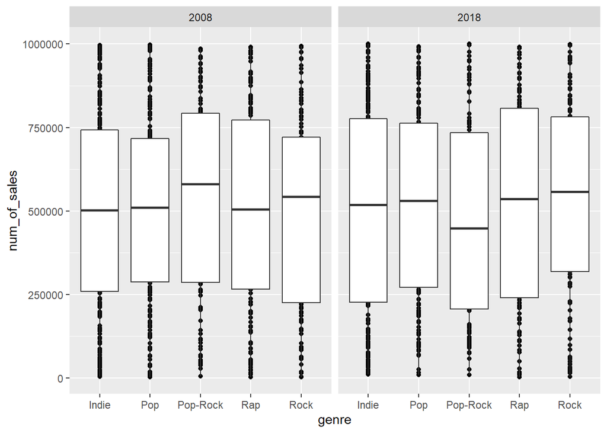

```r
# Draw a box plot graph that displays the five gruops' difference of sales in 2008 and 2018.
new %>%
  filter(genre %in% c("Indie","Pop","Rap","Rock","Pop-Rock"),
         year_of_pub %in%  c("2018","2008")) %>%
  select(genre, year_of_pub, num_of_sales) %>%
  ggplot( aes(x = genre, y = num_of_sales )) +
  geom_point() +
  geom_boxplot() +
  facet_wrap(~year_of_pub)
```

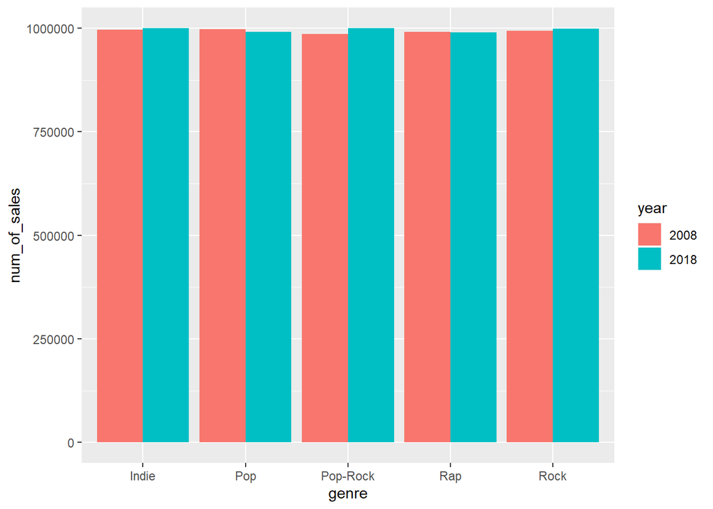

```r
# Box plot might be a little hard to see, here is the side by side bar graph:

new %>%
  filter(genre %in% c("Indie","Pop","Rap","Rock","Pop-Rock"),
         year_of_pub %in%  c(2008,2018)) %>%
  select(genre, year_of_pub, num_of_sales)%>%
  mutate(year = as.factor(year_of_pub)) %>%
  ggplot( aes(x= genre, y= num_of_sales ,fill = year)) +
  geom_bar(stat = "identity", position = "dodge")
```

### *Answer:* based on the boxplot and bar chart above, there seems to have no significant change between the number of sales in 2008 and 2018. Therefore, they were as popular as they are right now 10 year before.

### *Research Question 3:* Find the popularity of these top5 genre from 2000 - 2018 instead just comparing two individual years.

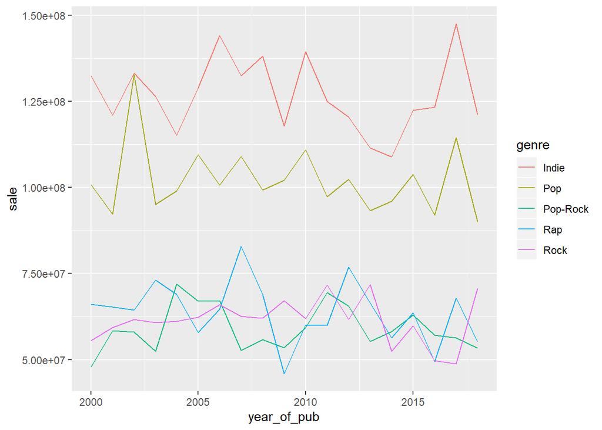

```r
new %>%
  filter(genre %in% c("Indie","Pop","Rap","Rock","Pop-Rock")) %>%
  select(genre,year_of_pub,num_of_sales) %>%
  group_by(genre, year_of_pub) %>%
  summarise(sale = sum(num_of_sales)) %>%
  ggplot( aes(year_of_pub ,sale ) ) +
  geom_line( aes(color = genre) )
```

### *Answer:* based on the graph above, Indie has always lead the number of sales over the 18 years. Around 2002, Pop catches up for a while but eventually droped to number 2, and kept the sliver medal from then on. For Pop-rock, Rap, Rock, they seem to constantly running neck and neck with each other for the honur of the bronze medal. It’s hard to tell whcih one wins, but we do see around 2006 to 2007, the rap genre leads the sale for a while.

### *Research Question 4:* Does televison channel or music critics magzine like those 5 genres ?

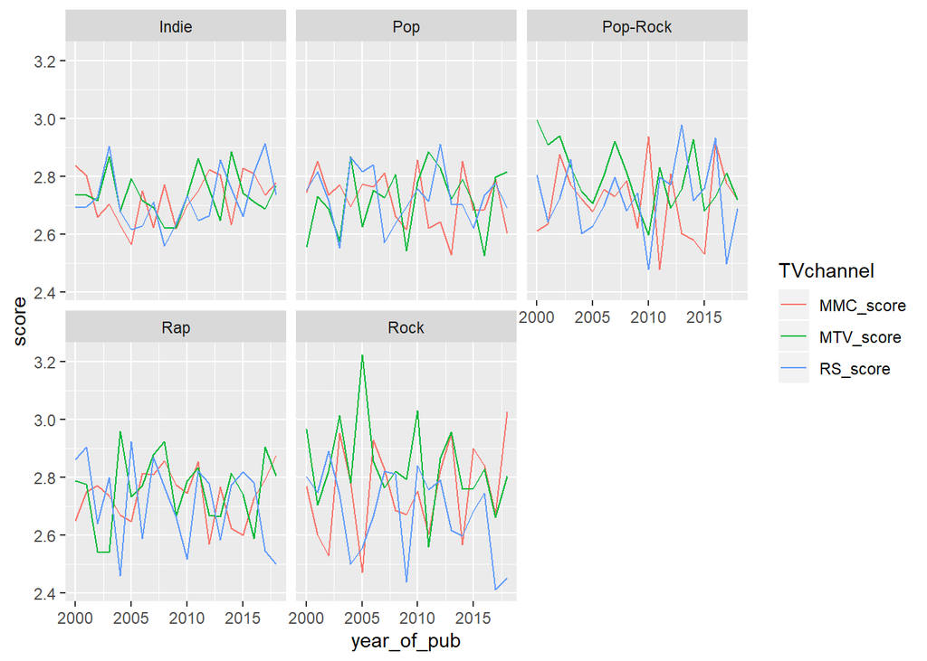

```r
new %>%
  filter(genre %in% c("Indie","Pop","Rap","Rock","Pop-Rock")) %>%
  select(genre,year_of_pub, rolling_stone_critic, mtv_critic, music_maniac_critic) %>%
  group_by(genre,year_of_pub) %>%
  summarise( RS_score = mean(rolling_stone_critic),
             MTV_score = mean(mtv_critic),
             MMC_score = mean(music_maniac_critic)) %>%
  pivot_longer(cols = ends_with("score"), names_to = "TVchannel",values_to = "score") %>%
  ggplot( aes (x= year_of_pub , y = score ) ) +
  geom_line( aes (color = TVchannel) ) +
  facet_wrap( ~ genre)
```

### *Answer:* based on the graph above, MMC, MTV and Rolling Stones tends to rate the music of Indie genre a score from 2.6 to around 2.9. And the rating is pretty stable through out the 18 years. The stroy for Pop is about the same, only the score can drop to 2.5. The Pop-Rock and Rap are pretty similar, ranging from 2.5 to 3. For Rock, the rating is not so stable. Around 2005, MTV tends to rate the music of Rock genre to 3.2 points, but around the same time, MMC only rates about 2.5.

### *Research Question 5:* How would you describe the relationship among the 36 genres in the data?

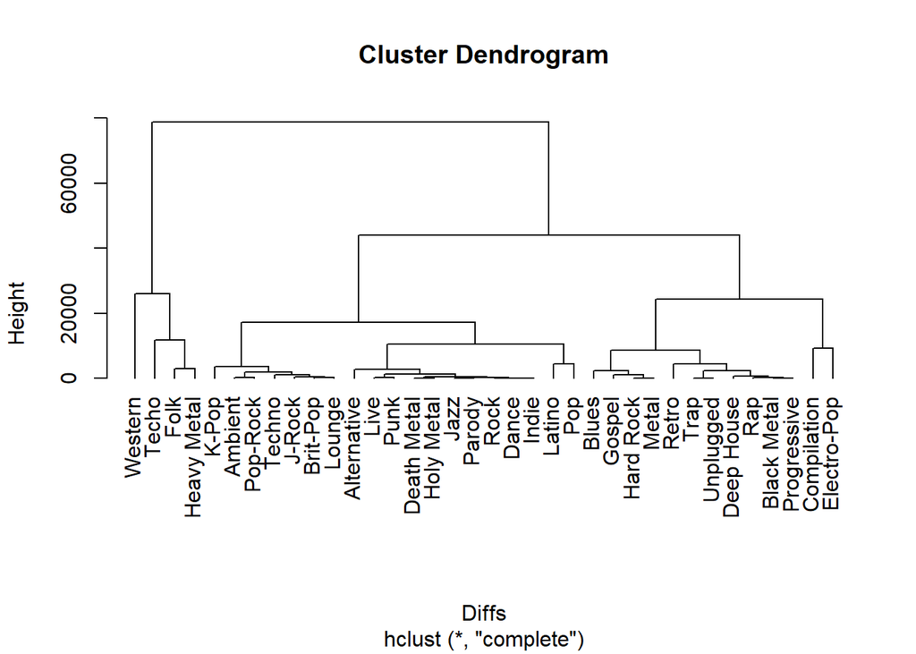

```r
cluster <-
  new %>%
  select(genre, year_of_pub, num_of_tracks, num_of_sales, rolling_stone_critic, mtv_critic, music_maniac_critic) %>%
  group_by(genre) %>%
  summarise( avg_tracks = mean(num_of_tracks),
             avg_sales = mean(num_of_sales),
             avg_RS = mean(rolling_stone_critic),
             avg_MTV = mean(mtv_critic),
             avg_MMC = mean(music_maniac_critic))


cluster <- column_to_rownames(cluster, var = "genre")

Diffs <- dist(cluster)
hc <- hclust(Diffs)
plot(hc, hang=-1)
```

### *Answer:* I used machine learning method to sort the relationship between the genres out, based on numeric variables including: average number of tracks per album, average sales over 2000 to 2018 and average critical rating they get. The result is presented as the Cluster Dendrogram above.